# RNA-Seq Data Analysis: Endogenous RAC1 P29S in mouse melanoma GSE118344

philip.east@crick.ac.uk

Compiled: 12 June, 2019 @ 17:11:35

```r
library( DESeq2 )
library( ggplot2 )
library( limma )
library( xlsx )
options( max.print=300, width=100 )
```

# Introduction

This R markdown document details the analysis of RNA-Seq data submitted to [GEO GES118344](https://www.ncbi.nlm.nih.gov/geo/query/acc.cgi?acc=GSE118344) and published in Cancer Cell 36, 1-16 July 8, 2019.

Transgenic mice with a conditional knock-in of the P29S mutation in the endogenous Rac1 locus were generated and crossed onto C57BL/6J, Tyr-CreER;BrafCA/wt;Ptenfl/wt mice. Melanomas were induced by topical 4OH-tamoxifen. We compared the gene expression profile in whole tumour lysates from Tyr-CreER+/-;Ptenfl/wt;BrafCA/wt;Rac1LSL-P29S/wt mice versus Tyr-CreER+/-;Ptenfl/wt;BrafCA/wt;Rac1wt/wt mice (n = 6 tumours from 5-6 animals per group).

# Load ExpressionSets

Here we load the data as ExpressionSet objects containing raw counts and TPMs.

```r
load( file = "eset_counts_GSE118344.rda" )
eset_counts
```

```
## ExpressionSet (storageMode: lockedEnvironment)
## assayData: 48795 features, 12 samples
##   element names: exprs
## protocolData: none
## phenoData
##   sampleNames: LIO312A7 LIO312A8 ... LIO312A18 (12 total)
##   varLabels: sample.id R1 ... experiment (6 total)
##   varMetadata: labelDescription
## featureData
##   featureNames: ENSMUST00000000001 ENSMUST00000000003 ... ENSMUST00000212350 (48795
##     total)
##   fvarLabels: seqnames start ... protein_version (31 total)
##   fvarMetadata: labelDescription
## experimentData: use 'experimentData(object)'
## Annotation:
```

```r
load( file = "eset_TPM_GSE118344.rda" )
eset_TPM
```

```
## ExpressionSet (storageMode: lockedEnvironment)
## assayData: 48795 features, 12 samples
##   element names: exprs
## protocolData: none
## phenoData
##   sampleNames: LIO312A7 LIO312A8 ... LIO312A18 (12 total)
##   varLabels: sample.id R1 ... experiment (6 total)
##   varMetadata: labelDescription
## featureData
##   featureNames: ENSMUST00000000001 ENSMUST00000000003 ... ENSMUST00000212350 (48795
##     total)
##   fvarLabels: seqnames start ... protein_version (31 total)
##   fvarMetadata: labelDescription
## experimentData: use 'experimentData(object)'
## Annotation:
```

# Experimental Design

```r
kable( pData( eset_counts ) )
```

|  | sample.id | R1 | R2 | label | gbg | experiment |
| --- | --- | --- | --- | --- | --- | --- |
| LIO312A7 | LIO312A7 | LIO312A7_S7_L001_R1_001.fastq.gz | LIO312A7_S7_L001_R2_001.fastq.gz | tum1 | wt | tum |
| LIO312A8 | LIO312A8 | LIO312A8_S8_L001_R1_001.fastq.gz | LIO312A8_S8_L001_R2_001.fastq.gz | tum2 | wt | tum |
| LIO312A9 | LIO312A9 | LIO312A9_S9_L001_R1_001.fastq.gz | LIO312A9_S9_L001_R2_001.fastq.gz | tum3 | wt | tum |
| LIO312A10 | LIO312A10 | LIO312A10_S10_L002_R1_001.fastq.gz | LIO312A10_S10_L002_R2_001.fastq.gz | tum4 | wt | tum |
| LIO312A11 | LIO312A11 | LIO312A11_S11_L002_R1_001.fastq.gz | LIO312A11_S11_L002_R2_001.fastq.gz | tum5 | wt | tum |
| LIO312A12 | LIO312A12 | LIO312A12_S12_L002_R1_001.fastq.gz | LIO312A12_S12_L002_R2_001.fastq.gz | tum6 | wt | tum |
| LIO312A13 | LIO312A13 | LIO312A13_S13_L002_R1_001.fastq.gz | LIO312A13_S13_L002_R2_001.fastq.gz | tum7 | mut | tum |
| LIO312A14 | LIO312A14 | LIO312A14_S14_L002_R1_001.fastq.gz | LIO312A14_S14_L002_R2_001.fastq.gz | tum8 | mut | tum |
| LIO312A15 | LIO312A15 | LIO312A15_S15_L002_R1_001.fastq.gz | LIO312A15_S15_L002_R2_001.fastq.gz | tum9 | mut | tum |
| LIO312A16 | LIO312A16 | LIO312A16_S16_L002_R1_001.fastq.gz | LIO312A16_S16_L002_R2_001.fastq.gz | tum10 | mut | tum |
| LIO312A17 | LIO312A17 | LIO312A17_S17_L002_R1_001.fastq.gz | LIO312A17_S17_L002_R2_001.fastq.gz | tum11 | mut | tum |
| LIO312A18 | LIO312A18 | LIO312A18_S18_L002_R1_001.fastq.gz | LIO312A18_S18_L002_R2_001.fastq.gz | tum12 | mut | tum |

# rlog count data

```r
rlog_mat <- DESeq2::rlog( exprs( eset_counts ) )
```

# Filter genes

Remove genes with a zero mean across all samples.

```r
f <- rowMeans( rlog_mat ) > 0
eset_counts <- eset_counts[ f, ]
eset_TPM <- eset_TPM[ f, ]
rlog_mat <- rlog_mat[ f, ]
```

# DESeq2 Analysis

To determine endogenous RAC1 mutant dependent transcriptional changes we ran a DESeq2 analysis across RAC1 mutant and wildtype samples. Differential genes were selected using a 0.05 fdr threshold.

```r
dds <- DESeqDataSetFromMatrix(countData = round( exprs( eset_counts ) ),
                              colData = pData( eset_counts ),
                              design = ~gbg )

dds <- DESeq( dds )
resobj <- results( dds, alpha = 0.05 )
res <- as.data.frame( resobj )
res <- res[ !is.na( res$padj ), ]
decide <- res[ res$padj < 0.05, ]
```

# Replicate group mean

Here we calculate mean log2 normalised counts across replicates.

```r
rld <- DESeq2::rlog( dds )
rgm <- do.call( 'cbind', by( t( assay( rld ) ), colData( dds )$gbg, function( mat ) {
    colMeans( mat )
} ) )
rgmTPM <- do.call( 'cbind', by( t( exprs( eset_TPM ) ), eset_TPM$gbg, function( mat ) {
    colMeans( mat )
} ) )
```

# Results

```r
genes <- rownames( decide )
dbase <- data.frame( gene = genes,
                    gene.symbol = fData( eset_counts[ genes, ] )$gene_name,
                    round( rgm[ genes, ], 3 ),
                    TPM = round( rgmTPM[ genes, ], 3 ),
                    log2FoldChange = decide[, "log2FoldChange" ],
                    p.value = decide[ , "pvalue" ],
                    fData( eset_counts[ genes, ] ) )
dbase[ is.na( dbase ) ] <- ""

write.xlsx( dbase, file = "RAC.vs.wt.melanoma.xlsx",
           sheetName = "RAC1vswt", row.names = FALSE )
```

# PCA

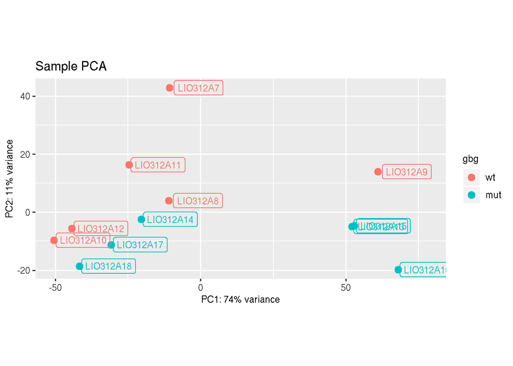

```r
gg <- plotPCA( rld,
              intgroup = "gbg",
              ntop = 1000 ) +
    labs( title = "Sample PCA", color="gbg" )
gg <- gg + geom_label( label = eset_counts$sample.id,
                      alpha = 0.2,
                      nudge_x = 10 )
gg
```